# Power calculation for stroke diagnosis in acute vertigo

A ‘druggable-MI-targets’ project

[Sander W. van der Laan, PhD](https://swvanderlaan.github.io) | @swvanderlaan | s.w.vanderlaan@gmail.com

2021-03-04

# Setup

We will clean the environment, setup the locations, define colors, and create a datestamp.

*Clean the environment.*

*Set locations and working directories…*

```
Create a new analysis directory...
[1] FALSE
[1] FALSE
[1] FALSE
[1] "/Users/slaan3/PLINK/analyses/grants/power_median"
[1] "20210303.VERTIGOPOWER.results.RData" "LICENSE"
[3] "power_median.nb.html"                "power_median.Rmd"
[5] "power_median.Rproj"                  "README.html"
[7] "README.md"                           "VERTIGOPOWER"
```

*… a package-installation function …*

```r
install.packages.auto <- function(x) {
  x <- as.character(substitute(x))
  if(isTRUE(x %in% .packages(all.available = TRUE))) {
    eval(parse(text = sprintf("require(\"%s\")", x)))
  } else {
    # Update installed packages - this may mean a full upgrade of R, which in turn
    # may not be warrented.
    #update.install.packages.auto(ask = FALSE)
    eval(parse(text = sprintf("install.packages(\"%s\", dependencies = TRUE, repos = \"https://cloud.r-project.org/\")", x)))
  }
  if(isTRUE(x %in% .packages(all.available = TRUE))) {
    eval(parse(text = sprintf("require(\"%s\")", x)))
  } else {
    if (!requireNamespace("BiocManager"))
      install.packages("BiocManager")
    BiocManager::install() # this would entail updating installed packages, which in turned may not be warrented

    # Code for older versions of R (<3.5.0)
    # source("http://bioconductor.org/biocLite.R")
    # Update installed packages - this may mean a full upgrade of R, which in turn
    # may not be warrented.
    # biocLite(character(), ask = FALSE)
    eval(parse(text = sprintf("BiocManager::install(\"%s\")", x)))
    eval(parse(text = sprintf("require(\"%s\")", x)))
  }
}
```

*… and load those packages.*

```r
install.packages.auto("readr")
install.packages.auto("optparse")
install.packages.auto("tools")
install.packages.auto("dplyr")
install.packages.auto("tidyr")
install.packages.auto("naniar")

# To get 'data.table' with 'fwrite' to be able to directly write gzipped-files
# Ref: https://stackoverflow.com/questions/42788401/is-possible-to-use-fwrite-from-data-table-with-gzfile
# install.packages("data.table", repos = "https://Rdatatable.gitlab.io/data.table")
library(data.table)

install.packages.auto("tidyverse")
install.packages.auto("knitr")
install.packages.auto("DT")
install.packages.auto("eeptools")

# Install the devtools package from Hadley Wickham
install.packages.auto('devtools')

# for plotting
install.packages.auto("ggplot2")
install.packages.auto("ggpubr")
install.packages.auto("UpSetR")
devtools::install_github("thomasp85/patchwork")

# For power calculations
install.packages("estmeansd")
install.packages.auto("pwr")
```

*We will create a datestamp and define the Utrecht Science Park Colour Scheme*.

```r
Today = format(as.Date(as.POSIXlt(Sys.time())), "%Y%m%d")
Today.Report = format(as.Date(as.POSIXlt(Sys.time())), "%A, %B %d, %Y")

### UtrechtScienceParkColoursScheme
###
### WebsitetoconvertHEXtoRGB:http://hex.colorrrs.com.
### Forsomefunctionsyoushoulddividethesenumbersby255.
###
### No. Color                 HEX   (RGB)                                     CHR         MAF/INFO
###---------------------------------------------------------------------------------------
### 1     yellow                #FBB820 (251,184,32)                      =>    1       or 1.0>INFO
### 2     gold                #F59D10 (245,157,16)                    =>    2
### 3     salmon                #E55738 (229,87,56)                   =>    3       or 0.05<MAF<0.2 or 0.4<INFO<0.6
### 4     darkpink          #DB003F ((219,0,63)                   =>    4
### 5     lightpink         #E35493 (227,84,147)                      =>    5       or 0.8<INFO<1.0
### 6     pink                #D5267B (213,38,123)                    =>    6
### 7     hardpink          #CC0071 (204,0,113)                   =>    7
### 8     lightpurple       #A8448A (168,68,138)                      =>    8
### 9     purple                #9A3480 (154,52,128)                      =>    9
### 10  lavendel            #8D5B9A (141,91,154)                      =>    10
### 11  bluepurple        #705296 (112,82,150)                    =>    11
### 12  purpleblue        #686AA9 (104,106,169)               =>    12
### 13  lightpurpleblue #6173AD (97,115,173/101,120,180)    =>  13
### 14  seablue             #4C81BF (76,129,191)                      =>    14
### 15  skyblue             #2F8BC9 (47,139,201)                      =>    15
### 16  azurblue            #1290D9 (18,144,217)                      =>    16      or 0.01<MAF<0.05 or 0.2<INFO<0.4
### 17  lightazurblue     #1396D8 (19,150,216)                    =>    17
### 18  greenblue           #15A6C1 (21,166,193)                      =>    18
### 19  seaweedgreen      #5EB17F (94,177,127)                    =>    19
### 20  yellowgreen       #86B833 (134,184,51)                    =>    20
### 21  lightmossgreen  #C5D220 (197,210,32)                      =>    21
### 22  mossgreen           #9FC228 (159,194,40)                      =>    22      or MAF>0.20 or 0.6<INFO<0.8
### 23  lightgreen      #78B113 (120,177,19)                      =>    23/X
### 24  green                 #49A01D (73,160,29)                     =>    24/Y
### 25  grey                  #595A5C (89,90,92)                        =>  25/XY   or MAF<0.01 or 0.0<INFO<0.2
### 26  lightgrey           #A2A3A4 (162,163,164)                 =>    26/MT
###
### ADDITIONAL COLORS
### 27  midgrey         #D7D8D7
### 28  verylightgrey   #ECECEC"
### 29  white           #FFFFFF
### 30  black           #000000
###----------------------------------------------------------------------------------------------

uithof_color = c("#FBB820","#F59D10","#E55738","#DB003F","#E35493","#D5267B",
                 "#CC0071","#A8448A","#9A3480","#8D5B9A","#705296","#686AA9",
                 "#6173AD","#4C81BF","#2F8BC9","#1290D9","#1396D8","#15A6C1",
                 "#5EB17F","#86B833","#C5D220","#9FC228","#78B113","#49A01D",
                 "#595A5C","#A2A3A4", "#D7D8D7", "#ECECEC", "#FFFFFF", "#000000")

uithof_color_legend = c("#FBB820", "#F59D10", "#E55738", "#DB003F", "#E35493",
                        "#D5267B", "#CC0071", "#A8448A", "#9A3480", "#8D5B9A",
                        "#705296", "#686AA9", "#6173AD", "#4C81BF", "#2F8BC9",
                        "#1290D9", "#1396D8", "#15A6C1", "#5EB17F", "#86B833",
                        "#C5D220", "#9FC228", "#78B113", "#49A01D", "#595A5C",
                        "#A2A3A4", "#D7D8D7", "#ECECEC", "#FFFFFF", "#000000")
### ----------------------------------------------------------------------------
```

# Introduction

We aim to discover biomarkers that differentiate strokes from non-strokes in acute vertigo patients at the emergency department. Given the differences in stroke risk and vertigo presentation of the sexes, we aim to discover sex-specific biomarkers. For this study we will include around 800 patients, and expect a drop-out of roughly 10%. Approximately 10% of the total sample size will be cases, *i.e.* patients with stroke.

To this end, we need to calculate the sample size needed to find a significant difference (p < 0.05) with a power of >80% between groups.

Earlier studies provide some insight in the expected differences between groups. For instance Kartal *et al.* reported on S100B for differential diagnosis of stroke in vertigo patients[^1].

> **Abstract** *Objectives*: Vertigo is a common presenting complaint resulting from central or peripheral etiologies. Because central > causes may be life-threatening, ascertaining the nature of the vertigo is crucial in the emergency department (ED). With > a broad range of potential etiologies, distinguishing central causes from benign peripheral causes is a diagnostic > challenge. Cranial magnetic resonance imaging (MRI) is the recommended neuroimaging method when clinical findings are > ambiguous. However, MRI scanning for every patient with an uncertain diagnosis may not be efficient or possible. > Therefore, to improve ED resource utilization for patients with vertigo, there is a need to identify the subset most > likely to have MRI abnormalities. It has previously been shown that S100B protein provides a useful serum marker of > stroke, subarachnoid hemorrhage, and traumatic brain injury. This study evaluated whether S100B levels could predict > central causes of vertigo as identified by cranial MRI in the ED.

> *Methods*: This prospective, observational study was conducted with adult patients with acute-onset vertigo (within 6 > hours) in the ED of a teaching hospital in Kocaeli, Turkey. Patients with nausea or dizziness complaints without > previously known vertigo or cranial pathology, and who agreed to participate in the study, were included. Patients with > trauma or with neurologic findings that developed concurrent with their symptoms were excluded. Serum levels of S100B > were measured with an electrochemiluminescence immunoassay kit. All subjects underwent cranial MRI. The predictors of > positive MRI results were evaluated using logistic regression analysis. Sensitivity and specificity of S100B levels for > identifying subjects with central causes of vertigo on MRI were calculated with receiver operating characteristic (ROC) > curve.

> *Results*: Of the 82 subjects included in the study, 48 (58.5%) were female, and the mean (±SD) age was 51 (±16) years. > Thirty-one (37.8%) subjects had positive MRI results. Median (with interquartile range [IQR]) serum S100B levels were > significantly different between MRI-negative and MRI-positive groups (median = 27.00 pg/mL, IQR = 10.00 to 44.60 vs. > median = 60.94 pg/mL, IQR = 38.25 to 77.95, respectively; p = 0.04). In logistic regression analysis, subjective “he or > she is spinning” (p = 0.030, odds ratio [OR] = 1.63, 95% confidence interval [CI] = 1.38 to 2.49), systolic blood > pressure (sBP; p = 0.045, OR = 1.044, 95% CI = 1.021 to 1.080), and serum S100B level (p = 0.042, OR = 1.22, 95% CI = > 1.018 to 1.445) were found to be independent predictors of MRI abnormalities. In the ROC analysis, S100B > 30 pg/mL > predicted the clinical outcome with 83.9% sensitivity (95% CI = 66.3% to 94.5%) and 51.0% specificity (95% CI = 36.6% to > 65.2%). The area under the ROC curve was 0.774 (95% CI = 0.666 to 0.881).

> *Conclusions*: To the best of our knowledge this is the first study assessing the utility of serum S100B levels for > diagnosis of acute-onset vertigo. Serum S100B levels are associated with the presence of central causes of vertigo on > cranial MRI. However, serum S100B levels are not sufficiently sensitive to exclude candidates from cranial MRI.

The issue here is that we don’t have means and standard deviations, we have medians and interquartile ranges. However, there are methods that can estimate means and standard deviations from a null distribution.

For instance: - http://bmcmedresmethodol.biomedcentral.com/articles/10.1186/1471-2288-14-135 - https://cran.r-project.org/web/packages/estmeansd/estmeansd.pdf and https://github.com/stmcg/estmeansd

The latter method is based on [MacGrath et al. 2020](https://journals.sagepub.com/doi/full/10.1177/0962280219889080), and available as an `R`-package, `estmeansd`. We can is easily implement this.

# Load data

First we will get these data in some variables.

```r
median_stroke <- 60.9
q1_stroke <- 38.25
q3_stroke <- 77.95
n_stroke <- 31

median_nonstroke <- 27
q1_nonstroke <- 10
q3_nonstroke <- 44.6
n_nonstroke <- 51

sample_size = n_stroke + n_nonstroke

# Reference: - https://stats.stackexchange.com/questions/256456/how-to-calculate-mean-and-standard-deviation-from-median-and-quartiles
# (sd_stroke <- (q3_stroke - q1_stroke) / (2 * (qnorm((0.75 * n_stroke - 0.125) / (n_stroke + 0.25)))))
#
# (sd_nonstroke <- (q3_nonstroke - q1_nonstroke) / (2 * (qnorm((0.75 * n_nonstroke - 0.125) / (n_nonstroke + 0.25)))))
```

## Calculate standard deviation

Now we can estimate the standard deviation from the interquartile ranges using the `estmeansd` package.

```r
library(estmeansd)
# ?estmeansd::qe.mean.sd()
qe.stroke <- qe.mean.sd(med.val = median_stroke,
                        q1.val = q1_stroke,
                        q3.val = q3_stroke,
                        n = n_stroke)
qe.stroke
```

```
$est.mean
[1] 59.03333

$est.sd
[1] 29.42965
```

```r
qe.nonstroke <- qe.mean.sd(med.val = median_nonstroke,
                        q1.val = q1_nonstroke,
                        q3.val = q3_nonstroke,
                        n = n_nonstroke)
qe.nonstroke
```

```
$est.mean
[1] 27.2

$est.sd
[1] 25.64902
```

# Power for Kartal et al.

Now that we estimated mean and standard deviation in each group, we can estimate the power for the study from Kartal *et al.*

```r
# Referece: https://publicifsv.sund.ku.dk/~tag/Teaching/share/R-tutorials/Basic-statistics/Power.html
mu = qe.stroke$est.mean
mu0 = qe.nonstroke$est.mean
sd = mean(qe.stroke$est.sd, qe.nonstroke$est.sd)
cat("Average standard deviation:\n")
```

```
Average standard deviation:
```

```r
sd
```

```
[1] 29.42965
```

```r
cat("\nDifference between means:\n")
```

```
Difference between means:
```

```r
mu_delta = mu - mu0
mu_delta
```

```
[1] 31.83333
```

```r
alpha = 0.05
beta = 0.20
n = (sd*(qnorm(1-alpha/2)+qnorm(1-beta))/(mu-mu0))^2
# ceiling(n)
z=(mu-mu0)/sd*sqrt(n)

cat("\nEstimated power (range: 0 - 1):\n")
```

```
Estimated power (range: 0 - 1):
```

```r
(Power=pnorm(z-qnorm(1-alpha/2))+pnorm(-z-qnorm(1-alpha/2)))
```

```
[1] 0.800001
```

# Simulate power for Vertigo

Small studies, like Kartal *et al.* usually overestimate the true effects. There is tons of literature on this topic, for instance [Zhang Z., *et al.*](https://doi.org/10.1186/cc11919), [Button K.S., *et al.*](https://doi.org/10.1038/nrn3475), and [Thambisetty M., *et al.*](https://pubmed.ncbi.nlm.nih.gov/28119051/).

Thus, we expect that with larger studies the difference between groups will be smaller, and that the standard deviation will also change. Based on the data from Kartal *et al.* we can simulate some scenarios for a given power of 80%, and three standard deviations.

> Note, we assume that measurements of biomarkers are in pg/mL, like in Kartal *et al.*

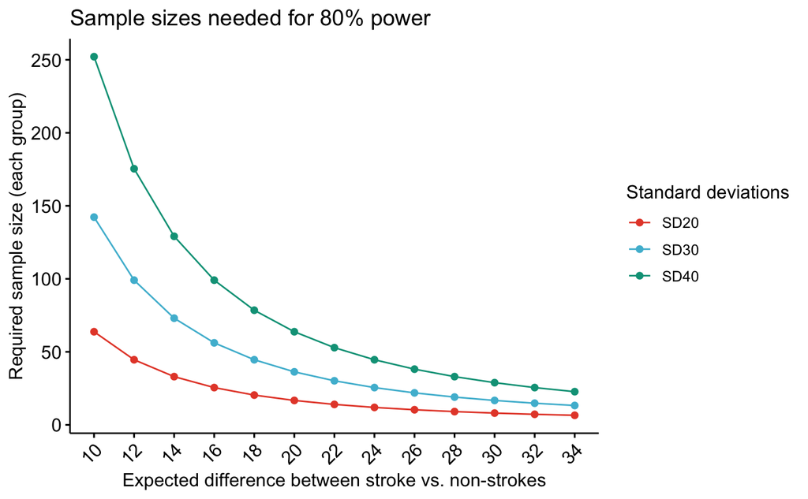

```r
differences <- seq(from = 10, to = 35, by = 2)
samplesize.sd20 <- sapply(differences,
                          function(d){power.t.test(power = 0.8,
                                                   delta = d,
                                                   sd = 20,
                                                   type = "two.sample")$n})
samplesize.sd30 <- sapply(differences,
                          function(d){power.t.test(power = 0.8,
                                                   delta = d,
                                                   sd = 30,
                                                   type = "two.sample")$n})

samplesize.sd40 <- sapply(differences,
                          function(d){power.t.test(power = 0.8,
                                                   delta = d,
                                                   sd = 40,
                                                   type = "two.sample")$n})

sim_vertigo_power <- data.frame(differences,
                                samplesize.sd20, samplesize.sd30, samplesize.sd40)
names(sim_vertigo_power)[names(sim_vertigo_power) == "samplesize.sd20"] <- "SD20"
names(sim_vertigo_power)[names(sim_vertigo_power) == "samplesize.sd30"] <- "SD30"
names(sim_vertigo_power)[names(sim_vertigo_power) == "samplesize.sd40"] <- "SD40"

p1 <- ggpubr::ggline(sim_vertigo_power,
                     x = "differences", c("SD20", "SD30", "SD40"),
                     merge = TRUE,
                     palette = "npg",
                     title = "Sample sizes needed for 80% power",
                     xlab = "Expected difference between stroke vs. non-strokes",
                     ylab = "Required sample size (each group)")
ggpar(p1,
      legend = "right", legend.title = "Standard deviations",
      # font.legend = c(10, "bold"),
      xtickslab.rt = 45)

ggsave(paste0(PLOT_loc, "/",PROJECTNAME,".power.png"), plot = last_plot())
```

# Conclusions

Based on this simulation and the Winner’s curse that exists for small sized studies we conclude the following:

“The expected difference between group is likely much smaller than the delta of 31 based on Kartal *et al.*; we expect it to be around 20 or smaller. Thus, for a power of >80%, with an expected total sample size of 720, a 10% case-rate, and to enable sex-stratified biomarker discovery, we would require 50-80 samples in each group.”

# Session information

```
Version:      v1.0.0
Last update:  2021-03-03
Written by:   Sander W. van der Laan (s.w.vanderlaan-2[at]umcutrecht.nl).
Description:  Script to get calculate power using published data.
Minimum requirements: R version 3.4.3 (2017-06-30) -- 'Single Candle', Mac OS X El Capitan

Changes log
* v1.0.0 Initial version.
```

# Saving environment

```r
save.image(paste0(PROJECT_loc, "/",Today,".",PROJECTNAME,".results.RData"))
```

| <sup>© 1979-2021 Sander W. van der Laan \| s.w.vanderlaan[at]gmail.com \| swvanderlaan.github.io.</sup> |
| --- |

[^1]: Kartal et al. https://doi.org/10.1111/acem.12420